# Google Trends Attention and Energy Sector ETF Returns

Petronela Tabalae & Marcel Reiber

12.05.2026

# 1 Introduction

Google search activity has become an increasingly relevant source of alternative data in empirical finance. Because internet search behavior reflects public and investor attention in near real time, Google Trends offers a publicly available proxy for how strongly a topic, company, or market segment is currently attracting interest. This has made search data attractive for financial research that aims to understand whether attention-based variables contain useful information about subsequent market developments.

At the same time, the empirical literature does not give a simple one-dimensional answer. Prior studies suggest that Google Trends is often more strongly related to market activity, such as trading volume and volatility, than to direct return predictability. In particular, Kim et al. (2019) show that Google searches do not explain or predict abnormal returns in the Norwegian stock market, but do predict future trading volume and volatility. Their results therefore suggest that Google search intensity may be more informative about future market activity than about future returns.

This project builds on that broader discussion but applies it to a sector-ETF setting. Instead of focusing on individual firms, the analysis studies U.S. sector ETFs as representative and liquid proxies for broad sector-level market behavior. This is useful because sector ETFs aggregate information from multiple stocks and may therefore offer a cleaner setting for studying the role of investor attention than individual-company time series.

Methodologically, the project follows the general framing described in the project notes: the same underlying model structure can be interpreted either as a forecasting exercise or as an influence analysis, depending on the narrative emphasis. The framing note suggests the general formulation “How does investor attention, measured by Google Trends search volume, influence the realized volatility of U.S. sector ETFs?” and highlights VAR and impulse-response analysis as the core methodological tools. In the present version of the project, the main focus is shifted from volatility to returns, because the central interest is whether Google Trends attention helps improve the prediction of future sector ETF returns.

The general research question of the project is therefore:

Does investor attention, measured by Google Trends search activity, improve forecasts of U.S. sector ETF returns?

The analysis is designed as a forecasting study. The main objective is not to establish strict causal effects in the econometric sense, but to test whether search-based attention variables add useful predictive information beyond the information already contained in financial return series themselves.

The main hypotheses are:

Null hypothesis ($H_0$): Google Trends attention does not improve forecasts of U.S. sector ETF returns. Alternative hypothesis ($H_A$): Google Trends attention improves forecasts of U.S. sector ETF returns.

A second objective of the project is to assess whether any attention-based predictive signal remains informative after accounting for broad market exposure. For this reason, the study also includes a Single Index Model as a benchmark side analysis. This benchmark helps distinguish between broad market-driven behavior and more sector-specific return dynamics.

# 2 Procedure and General Project Plan

The project follows a structured empirical workflow that can in principle be applied to several sectors. Although the present implementation starts with the energy sector, the same methodological design could later be extended to other sector ETFs as well.

# 3 Application to the Energy Sector

The energy sector is a natural starting point for this project because it is strongly exposed to macroeconomic, geopolitical, and commodity-related shocks. Investor attention is therefore likely to become visible during periods of oil price collapses, energy crises, or fuel-price surges. Compared with other sectors, the energy sector often reacts to highly salient external developments that also receive strong public attention.

From a practical perspective, the sector is also well suited for a first implementation:

- it has experienced several distinct market episodes in recent years
- relevant search terms are relatively intuitive and economically interpretable
- the corresponding sector ETF is easily accessible through Yahoo Finance

For the empirical analysis, the energy sector is represented by the ETF XLE.

XLE stands for the Energy Select Sector SPDR Fund. It is a widely used sector ETF that represents large U.S. energy companies and serves as a liquid market proxy for the U.S. energy equity sector.

The ETF is useful for this project because:

- it provides a broad sector representation rather than single-company noise
- it is directly available through standard financial data sources
- it avoids the need to manually construct a basket of energy stocks
- it offers a clean return series for time-series modeling

In the present project, XLE is used as the financial return variable in the first implementation of the general project framework.

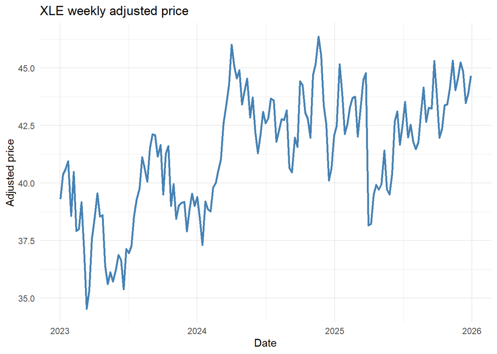

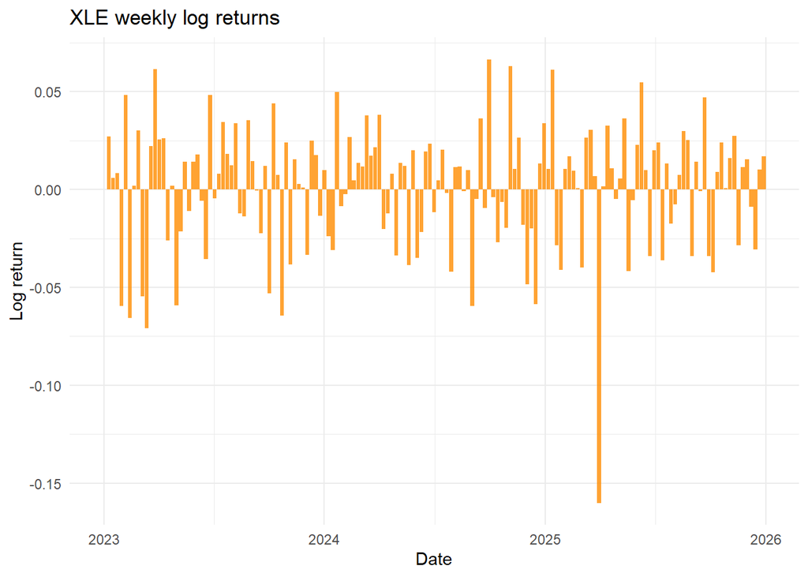

The descriptive plots show that XLE experienced noticeable fluctuations over the sample period from 2023 to 2025. The weekly adjusted price series suggests that the ETF moved within a relatively broad range, with phases of decline, recovery, and renewed volatility. The weekly return series confirms that short-term changes are centered around zero, but also includes several pronounced positive and negative shocks. This is particularly relevant for the subsequent analysis, as it shows that the return series contains enough variation to make a forecasting exercise meaningful. At the same time, the fact that returns fluctuate around zero rather than showing a persistent level trend is consistent with the idea that returns, rather than prices, are the more appropriate variable for time-series modeling.

# 4 Defining the Key Search Terms for the Energy Sector

To measure investor attention in the energy sector, a set of Google Trends keywords is defined and collected from Google Trends. The purpose of this step is not yet to estimate the final forecasting model, but to construct a first attention-based dataset and identify which search terms show sufficient variation over time to be useful for further analysis.

The initial keyword set is intentionally broad and combines several dimensions of attention that may matter for energy markets. These include:

- geopolitical developments, such as war, conflict, and Iran
- oil-market and pricing terms, such as WTI price, oil price, and Brent oil
- supply- and inventory-related terms, such as crude inventories
- gas-market terms, such as LNG and natural gas

This broader list is used as a screening stage. The goal is to inspect which series are available, which show meaningful dynamics, and which appear most relevant for constructing a combined attention index for the energy sector.

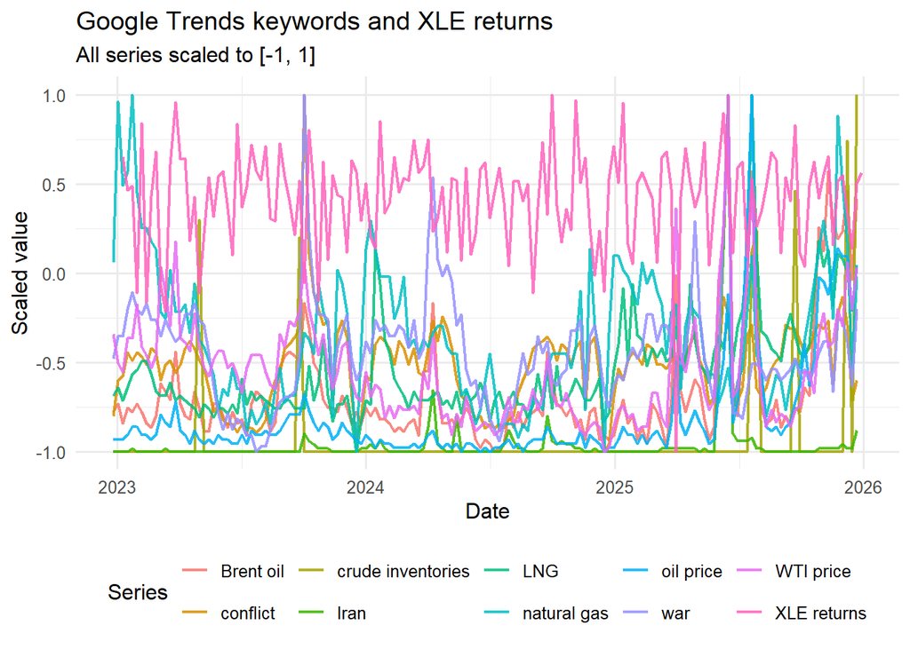

The keyword plot shows that the Google Trends series differ substantially in both level and volatility. Some terms remain relatively stable over time, while others show pronounced spikes that may reflect periods of elevated public or investor attention. In particular, several keywords exhibit stronger movements during 2025, which suggests that energy-related search intensity increased notably in that period.

This screening step is useful because not all search terms are equally informative. Some keywords may be too broad, too noisy, or too event-specific, while others may better reflect persistent attention to energy-market developments. Based on this visual inspection and the subsequent comparison with XLE returns, a smaller subset of keywords is selected for the construction of the combined attention index.

After the initial keyword screening, a smaller subset of search terms is selected for the construction of the final energy attention measure. The purpose of this step is to reduce noise and combine the most relevant Google Trends series into one single indicator that can be used in the later forecasting models.

To make the keywords comparable, each series is first standardized. This is necessary because the Google Trends indices of different search terms can have different average levels and variability. After standardization, the selected keyword series are averaged by week to obtain one combined attention index. This index is intended to summarize general investor and public attention to energy-related developments in a compact form.

```
## # A tibble: 12 × 2
##    week       attention_index
##    <date>               <dbl>
##  1 2022-12-26          0.0449
##  2 2023-01-02          0.774
##  3 2023-01-09          0.404
##  4 2023-01-16          0.648
##  5 2023-01-23          1.07
##  6 2023-01-30          0.659
##  7 2023-02-06          0.551
##  8 2023-02-13          0.602
##  9 2023-02-20          0.409
## 10 2023-02-27          0.296
## 11 2023-03-06         -0.0305
## 12 2023-03-13          0.0208
```

The resulting attention index provides one weekly attention measure for each period in the sample. Positive values indicate weeks in which the selected search terms were, on average, more strongly searched than usual, while negative values indicate below-average search attention. By combining several related keywords into one standardized index, the analysis reduces the influence of isolated keyword-specific noise and creates a single explanatory variable that can be compared directly with the weekly XLE return series in the subsequent modeling steps.

In the next step, the combined attention index is merged with the weekly XLE dataset. This creates one joint time-series dataset containing the ETF price, weekly return, and the Google Trends-based attention measure for each week. Establishing this merged dataset is necessary before conducting the stationarity checks, forecasting regressions, and VAR analysis.

```
## # A tibble: 12 × 4
##    week       price log_return attention_index
##    <date>     <dbl>      <dbl>           <dbl>
##  1 2023-01-02  39.3   NA                0.774
##  2 2023-01-09  40.4    0.0269           0.404
##  3 2023-01-16  40.6    0.00587          0.648
##  4 2023-01-23  40.9    0.00826          1.07
##  5 2023-01-30  38.6   -0.0595           0.659
##  6 2023-02-06  40.5    0.0483           0.551
##  7 2023-02-13  37.9   -0.0655           0.602
##  8 2023-02-20  38.0    0.00201          0.409
##  9 2023-02-27  39.2    0.0302           0.296
## 10 2023-03-06  37.1   -0.0545          -0.0305
## 11 2023-03-13  34.5   -0.0710           0.0208
## 12 2023-03-20  35.3    0.0223           0.213
```

```
##       Min.    1st Qu.     Median       Mean
## -1.0259513 -0.4915792 -0.0286276 -0.0002875
##    3rd Qu.       Max.       NA's
##  0.3023027  2.5225349          1
```

```
## [1] 1
```

The merged dataset confirms that the market data and the constructed attention index can be aligned on a common weekly time scale. As expected, the first weekly return observation is missing because returns are computed from price changes and therefore require a lagged value. In addition, the attention index contains only one missing value, which indicates that the merge was largely successful. This combined dataset forms the basis for the subsequent time-series analysis.

After merging the ETF data and the weekly attention index, both series can be compared directly over time. Since weekly returns and the attention index are measured on different scales, both variables are normalized to a common range before plotting. This allows a purely visual comparison of whether periods of elevated search attention tend to occur at the same time as, or shortly before, stronger fluctuations in XLE returns.

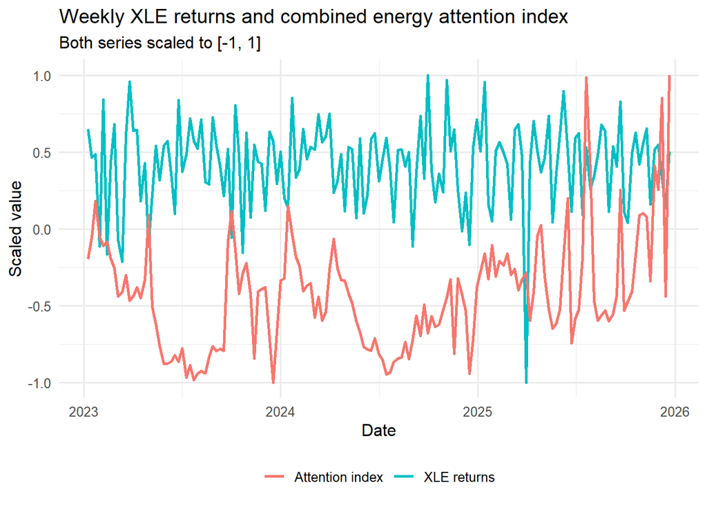

# 5 Checking Stationarity

Before estimating the forecasting models, it is necessary to examine whether the main time series are stationary. Many standard time-series methods, including autoregressive models and VAR models, require stationary input series in order to avoid misleading or spurious results. For this reason, Augmented Dickey-Fuller (ADF) tests are applied to the weekly XLE price series, the weekly XLE return series, and the combined Google Trends attention index.

```
##
##  Augmented Dickey-Fuller Test
##
## data:  na.omit(xle_weekly$price)
## Dickey-Fuller = -3.0871, Lag order = 5,
## p-value = 0.1231
## alternative hypothesis: stationary
```

```
##
##  Augmented Dickey-Fuller Test
##
## data:  na.omit(xle_weekly$log_return)
## Dickey-Fuller = -6.3401, Lag order = 5,
## p-value = 0.01
## alternative hypothesis: stationary
```

```
##
##  Augmented Dickey-Fuller Test
##
## data:  na.omit(xle_attention_weekly$attention_index)
## Dickey-Fuller = -2.6072, Lag order = 5,
## p-value = 0.3232
## alternative hypothesis: stationary
```

Own notices: XLE price: not stationary, p-value = 0.1231, which is above 0.05. This is expected for a price level series.

XLE return: stationary, p-value = 0.01, clearly below 0.05. This is good, because weekly log returns are the main dependent variable in the analysis.

General interpretation: More negative Dickey-Fuller statistics usually indicate stronger evidence against non-stationarity. Here, the return series shows the strongest evidence of stationarity, while the price series and the attention index do not provide sufficient evidence of stationarity.

The ADF results show clear differences across the three series. As expected, the weekly XLE price level is not stationary (p=0.1231), which is typical for financial price series and confirms that price levels should not be used directly in the VAR specification. In contrast, the weekly XLE return series is stationary (p=0.01), making it suitable as the main dependent variable in the subsequent analysis. The combined attention index in levels is also not stationary (p=0.3232), which implies that it must be transformed before it can be included in the VAR. Therefore, the next step is to difference the attention index and test the transformed series again.

```
##       Min.    1st Qu.     Median       Mean
## -1.0259513 -0.4915792 -0.0286276 -0.0002875
##    3rd Qu.       Max.       NA's
##  0.3023027  2.5225349          1
```

```
## [1] 1
```

```
##  [1] "2023-01-02" "2023-01-09" "2023-01-16"
##  [4] "2023-01-23" "2023-01-30" "2023-02-06"
##  [7] "2023-02-13" "2023-02-20" "2023-02-27"
## [10] "2023-03-06"
```

```
##  [1] "2022-12-26" "2023-01-02" "2023-01-09"
##  [4] "2023-01-16" "2023-01-23" "2023-01-30"
##  [7] "2023-02-06" "2023-02-13" "2023-02-20"
## [10] "2023-02-27"
```

```
##  [1] "2025-10-27" "2025-11-03" "2025-11-10"
##  [4] "2025-11-17" "2025-11-24" "2025-12-01"
##  [7] "2025-12-08" "2025-12-15" "2025-12-22"
## [10] "2025-12-29"
```

```
##  [1] "2025-10-20" "2025-10-27" "2025-11-03"
##  [4] "2025-11-10" "2025-11-17" "2025-11-24"
##  [7] "2025-12-01" "2025-12-08" "2025-12-15"
## [10] "2025-12-22"
```

Because the attention index in levels was found to be non-stationary, it must be transformed before it can be used in the VAR framework. A common way to achieve stationarity is to take the first difference of the series. In this case, the weekly change in the attention index is calculated by subtracting the previous week’s value from the current week’s value. This transformed series, denoted as “attention_diff”, is then used in the subsequent stationarity test and modeling steps.

```
##     Min.  1st Qu.   Median     Mean  3rd Qu.
## -2.28733 -0.21464  0.02590  0.01128  0.18701
##     Max.     NA's
##  2.54927        2
```

```
## [1] 2
```

```
## # A tibble: 12 × 5
##    week       price log_return attention_index
##    <date>     <dbl>      <dbl>           <dbl>
##  1 2023-01-02  39.3   NA                0.774
##  2 2023-01-09  40.4    0.0269           0.404
##  3 2023-01-16  40.6    0.00587          0.648
##  4 2023-01-23  40.9    0.00826          1.07
##  5 2023-01-30  38.6   -0.0595           0.659
##  6 2023-02-06  40.5    0.0483           0.551
##  7 2023-02-13  37.9   -0.0655           0.602
##  8 2023-02-20  38.0    0.00201          0.409
##  9 2023-02-27  39.2    0.0302           0.296
## 10 2023-03-06  37.1   -0.0545          -0.0305
## 11 2023-03-13  34.5   -0.0710           0.0208
## 12 2023-03-20  35.3    0.0223           0.213
## # ℹ 1 more variable: attention_diff <dbl>
```

The differenced attention series appears well-behaved and contains only two missing values, which are expected because differencing requires lagged observations. The summary statistics show that the transformed series fluctuates around zero, with both positive and negative weekly changes in search attention. This is consistent with the interpretation of attention_diff as a short-term change measure rather than a level measure. The next step is to test whether this differenced series is stationary and therefore suitable for inclusion in the VAR model.

Since the attention index in levels is not stationary, the differenced series must also be tested formally. An Augmented Dickey-Fuller test is therefore applied to the weekly change in the attention index.

```
##
##  Augmented Dickey-Fuller Test
##
## data:  attention_diff_clean
## Dickey-Fuller = -6.5646, Lag order = 5,
## p-value = 0.01
## alternative hypothesis: stationary
```

The ADF test confirms that the differenced attention series is stationary (p=0.01). This means that the transformed attention variable can be used together with weekly XLE log returns in the subsequent VAR analysis.

# 6 Modelling

After establishing that weekly XLE returns and the differenced attention index are both stationary, a clean modeling dataset can be constructed. This dataset contains only the variables needed for the subsequent time-series models and excludes observations with missing values.

```
## # A tibble: 12 × 3
##    week       log_return attention_diff
##    <date>          <dbl>          <dbl>
##  1 2023-01-09    0.0269         -0.370
##  2 2023-01-16    0.00587         0.244
##  3 2023-01-23    0.00826         0.421
##  4 2023-01-30   -0.0595         -0.410
##  5 2023-02-06    0.0483         -0.109
##  6 2023-02-13   -0.0655          0.0511
##  7 2023-02-20    0.00201        -0.193
##  8 2023-02-27    0.0302         -0.113
##  9 2023-03-06   -0.0545         -0.327
## 10 2023-03-13   -0.0710          0.0513
## 11 2023-03-20    0.0223          0.192
## 12 2023-03-27    0.0615         -0.291
```

```
##       week              log_return
##  Min.   :2023-01-09   Min.   :-0.1600463
##  1st Qu.:2023-10-05   1st Qu.:-0.0188116
##  Median :2024-07-01   Median : 0.0080750
##  Mean   :2024-07-01   Mean   : 0.0007167
##  3rd Qu.:2025-03-27   3rd Qu.: 0.0201549
##  Max.   :2025-12-22   Max.   : 0.0664435
##  attention_diff
##  Min.   :-2.28733
##  1st Qu.:-0.21464
##  Median : 0.02590
##  Mean   : 0.01128
##  3rd Qu.: 0.18701
##  Max.   : 2.54927
```

The resulting VAR dataset contains weekly observations for the stationary return series and the stationary change in the attention index. This confirms that the data are now in the appropriate form for the autoregressive benchmark model, lag-order selection, and the VAR estimation.

## 6.1 Estimating a simple benchmark model

```
##
## Call:
## lm(formula = log_return ~ return_lag1, data = ar_data)
##
## Residuals:
##       Min        1Q    Median        3Q
## -0.160011 -0.017018  0.006511  0.019126
##       Max
##  0.064923
##
## Coefficients:
##               Estimate Std. Error t value
## (Intercept)  0.0006087  0.0025510   0.239
## return_lag1 -0.0948060  0.0805858  -1.176
##             Pr(>|t|)
## (Intercept)    0.812
## return_lag1    0.241
##
## Residual standard error: 0.03165 on 152 degrees of freedom
## Multiple R-squared:  0.009023,   Adjusted R-squared:  0.002504
## F-statistic: 1.384 on 1 and 152 DF,  p-value: 0.2413
```

The autoregressive benchmark model shows that the first lag of weekly XLE returns does not significantly explain current weekly returns. The coefficient on return_lag1 is negative, but statistically insignificant (p=0.241). In addition, the model explains only a very small share of return variation (R 2 =0.009). This suggests that past XLE returns alone contain little predictive information in the current sample and therefore provide only a weak benchmark for comparison with the later multivariate models.

## 6.2 Choosing the Lag Length with AIC, BIC, and HQ

```
## $selection
## AIC(n)  HQ(n)  SC(n) FPE(n)
##      3      3      1      3
##
## $criteria
##                    1            2
## AIC(n) -8.1443202043 -8.145737268
## HQ(n)  -8.0947265230 -8.063081133
## SC(n)  -8.0222617314 -7.942306480
## FPE(n)  0.0002903833  0.000289984
##                    3             4
## AIC(n) -8.2123128161 -8.1957302090
## HQ(n)  -8.0965942262 -8.0469491649
## SC(n)  -7.9275097126 -7.8295547902
## FPE(n)  0.0002713317  0.0002759134
##                    5            6
## AIC(n) -8.1648604711 -8.130950893
## HQ(n)  -7.9830169728 -7.916044941
## SC(n)  -7.7173127370 -7.602030844
## FPE(n)  0.0002846359  0.000294561
##                    7             8
## AIC(n) -8.0955304041 -8.0482044553
## HQ(n)  -7.8475619973 -7.7671735942
## SC(n)  -7.4852380395 -7.3565397754
## FPE(n)  0.0003053338  0.0003203407
```

The autoregressive benchmark model shows little predictive content. Lagged XLE returns are not statistically significant, and the model explains only a very small share of return variation.

## 6.3 Estimate VAR

```
##
## VAR Estimation Results:
## =========================
## Endogenous variables: log_return, attention_diff
## Deterministic variables: const
## Sample size: 153
## Log Likelihood: 198.786
## Roots of the characteristic polynomial:
## 0.4322 0.4322 0.3505 0.3505
## Call:
## VAR(y = var_input, p = 2, type = "const")
##
##
## Estimation results for equation log_return:
## ===========================================
## log_return = log_return.l1 + attention_diff.l1 + log_return.l2 + attention_diff.l2 + const
##
##                    Estimate Std. Error
## log_return.l1     -0.110082   0.081288
## attention_diff.l1 -0.002070   0.005149
## log_return.l2     -0.183603   0.081280
## attention_diff.l2 -0.000787   0.005499
## const              0.000725   0.002548
##                   t value Pr(>|t|)
## log_return.l1      -1.354   0.1777
## attention_diff.l1  -0.402   0.6882
## log_return.l2      -2.259   0.0254 *
## attention_diff.l2  -0.143   0.8864
## const               0.285   0.7764
## ---
## Signif. codes:
## 0 '***' 0.001 '**' 0.01 '*' 0.05 '.' 0.1 ' ' 1
##
##
## Residual standard error: 0.03149 on 148 degrees of freedom
## Multiple R-Squared: 0.0447,  Adjusted R-squared: 0.01888
## F-statistic: 1.731 on 4 and 148 DF,  p-value: 0.1461
##
##
## Estimation results for equation attention_diff:
```

[output cut: 20 more lines]

```
## Residual standard error: 0.5275 on 148 degrees of freedom
## Multiple R-Squared: 0.1019,  Adjusted R-squared: 0.07759
## F-statistic: 4.196 on 4 and 148 DF,  p-value: 0.00301
##
##
##
## Covariance matrix of residuals:
##                log_return attention_diff
## log_return      0.0009916       0.001837
## attention_diff  0.0018374       0.278235
##
## Correlation matrix of residuals:
##                log_return attention_diff
## log_return         1.0000         0.1106
## attention_diff     0.1106         1.0000
```

The VAR(2) results provide little evidence that changes in Google Trends attention help explain weekly XLE returns. In the return equation, neither the first nor the second lag of attention_diff is statistically significant, while only the second lag of returns is significant at the 5% level. The explanatory power of the return equation remains low (R 2 =0.045), which suggests that the model captures only a small fraction of weekly return variation.

In contrast, the equation for attention_diff shows that the attention series is mainly driven by its own past values. The first lag of attention_diff is highly significant, while the second lag is not statistically significant. Lagged returns are not significant in this equation. This indicates that short-term changes in search attention mainly follow their own internal dynamics rather than being influenced by past XLE returns. Overall, the VAR results do not suggest a meaningful predictive contribution of the Google Trends attention measure for weekly energy-sector returns.

## 6.4 Granger Causality Test

```
## $Granger
##
##  Granger causality H0: attention_diff do
##  not Granger-cause log_return
##
## data:  VAR object var_model
## F-Test = 0.08312, df1 = 2, df2 = 296,
## p-value = 0.9203
##
##
## $Instant
##
##  H0: No instantaneous causality between:
##  attention_diff and log_return
##
## data:  VAR object var_model
## Chi-squared = 1.8496, df = 1, p-value =
## 0.1738
```

The Granger causality test confirms the earlier VAR findings. The null hypothesis that changes in the attention index do not Granger-cause weekly XLE returns cannot be rejected (p=0.9203). This means that past changes in Google Trends attention do not provide statistically significant predictive information for future XLE returns in this specification.

The test for instantaneous causality is also insignificant (p=0.1738), indicating that there is no evidence of a contemporaneous relationship between the two variables beyond what is already captured in the model. Overall, the causality results suggest that the selected Google Trends attention measure does not improve the prediction of weekly XLE returns.

## 6.5 Impulse Response Function

To complement the coefficient-based VAR interpretation, an impulse response analysis is performed. The impulse response function (IRF) traces how weekly XLE returns react over the following weeks to a one-time shock in the differenced attention index. This provides a more dynamic view of the relationship and helps assess whether a sudden increase in search attention leads to a meaningful response in energy-sector returns over time.

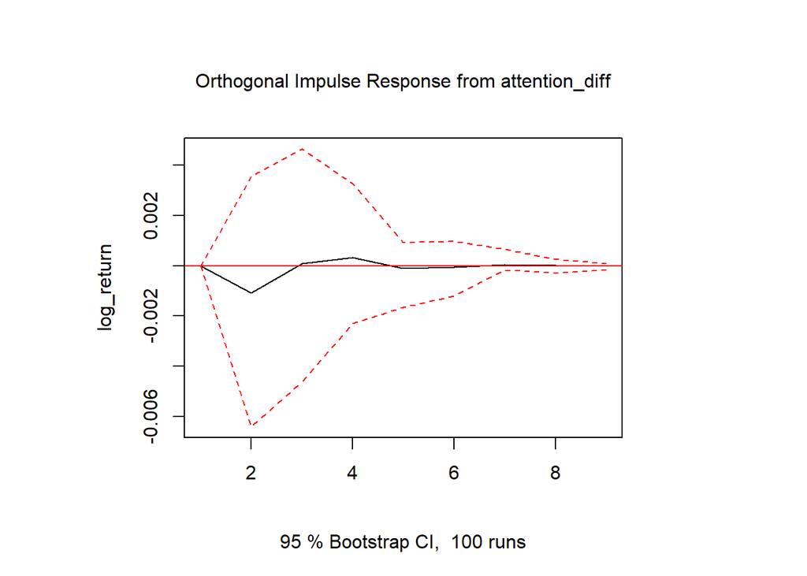

The impulse response function suggests that a shock in the differenced attention index has only a small and short-lived effect on weekly XLE returns. Although the estimated response fluctuates slightly around zero in the following weeks, the confidence bands include zero throughout the horizon. This indicates that the return response is not statistically distinguishable from zero. The IRF therefore reinforces the earlier results from the VAR coefficients and the Granger causality test: the constructed Google Trends attention measure does not appear to have a meaningful dynamic effect on weekly XLE returns in the current specification.

## 6.6 Forecasting Check

To evaluate whether Google Trends attention provides practical forecasting value, an out-of-sample forecast comparison was conducted. A benchmark model using only lagged returns was compared with an augmented model that additionally included lagged changes in the attention index. Forecast performance was assessed using RMSE and MAE on a holdout sample. This comparison complements the VAR and Granger results by testing whether the attention variable improves predictive accuracy in practice.

```
## # A tibble: 2 × 3
##   Model                            RMSE    MAE
##   <chr>                           <dbl>  <dbl>
## 1 Benchmark: returns only        0.0327 0.0226
## 2 Augmented: returns + attention 0.0337 0.0242
```

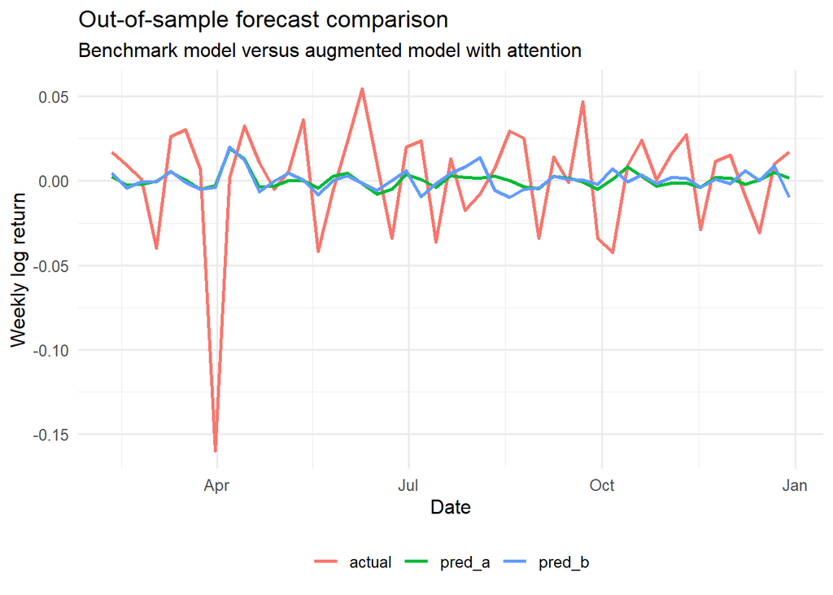

The out-of-sample forecast comparison shows that the augmented model including Google Trends attention performs worse than the benchmark model based only on lagged returns. Both RMSE and MAE are higher for the augmented model, indicating that the attention variable does not improve forecast accuracy for weekly XLE returns in the current specification.

# 7 Conclusion